# GoBike's Bike Renter

## by Petar Janosevic

## Investigation Overview

> In this dataset I wanted to find out who GoBike's bike renter are. I wanted to know the relationship between genders and ages. My main interest was to find out more about GoBike's main customer/subscribers and what do they use the bikes for the most. My assumption ist that most people use GoBike to commute.

## Dataset Overview

> This dataset has 183'412 rentals which include the duration of riding the bike, some informations about the bike user like gender and user type, start and end stations etc.. The location is the San Francisco Bay area.

## Mean Duration

The chart is plotted on a logarithmic scale and represents the mean duration in seconds. The distribution is unimodal. It's right skewed and the mean lies near 700 which means that people tend to rent bikes for circa 12 minutes. This is a pro fact for the commuting argument.

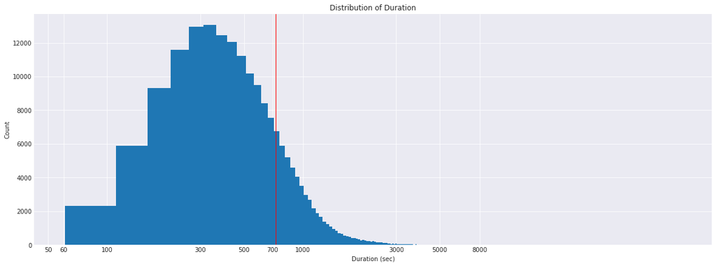

## Mean Duration per Day

This bar chart shows the mean duration distribution on every day of the week. The mean is much higher on the weekend than during the week. The mean for weekdays is lower and for weekends higher than the actual mean. This can be explained with the fact that people use bikes during the week to commute.

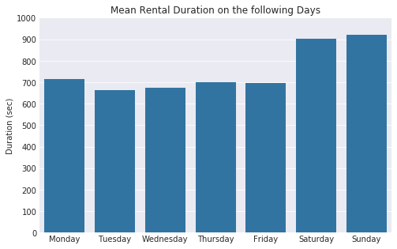

## Hourly Rentals

This is a timeplot which represents when a bike was rent by the exact hour. We can see that this chart is bimodal, having two peeks in the morning and evening. These two peeks stand for rush hour periods. During rush hour people commute the most. This strenghtens the argument of people mostly using GoBike for commuting to work, school etc..

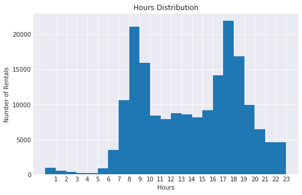

## Amount of Rentals by Different Age Stages and User Types

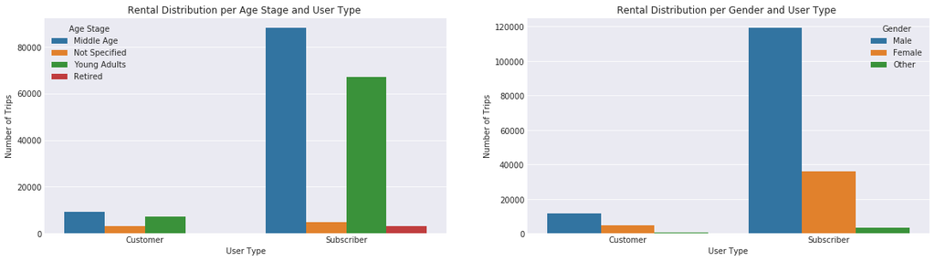

## Mean Distribution by Different Age Stages and User Types

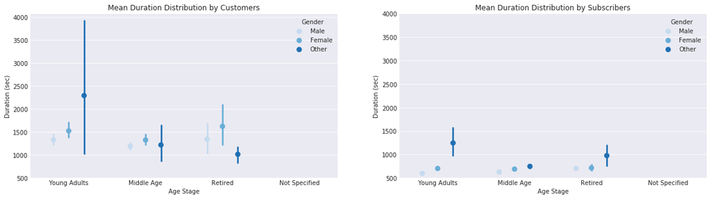